# NSCI7915 Preliminary Analysis

2023-05-20

**Hypothesis 1: The abundance of H.perlevis is influenced by month**

Metadata: Nudibranch predation boosts sponge silicon cycling (2023)

Dependent variable (D) = Abundance (n)

Null Hypothesis (H0): There is no significant relationship between the abundance of Hymeniacidon perlevis and the month.

Alternative Hypothesis (HA): There is a relationship between the abundance of Hymeniacidon perlevis and the month.

*Table 1: Statistical summary of abundance and volume data from the 2023 study*

```
##    N.quadrat      N.H..perlevis   Volumen.Hym..mL.     Date
##  Min.   : 1.000   Min.   : 3.00   Min.   :  1.90   Length:71
##  1st Qu.: 5.000   1st Qu.:12.00   1st Qu.: 27.35   Class :character
##  Median : 9.000   Median :20.00   Median : 62.60   Mode  :character
##  Mean   : 9.789   Mean   :23.58   Mean   :120.08
##  3rd Qu.:14.000   3rd Qu.:31.00   3rd Qu.:167.85
##  Max.   :22.000   Max.   :73.00   Max.   :690.50
##
##     X               row_id
##  Mode:logical   1      : 1
##  NA's:71        2      : 1
##                 3      : 1
##                 4      : 1
##                 5      : 1
##                 6      : 1
##                 (Other):65
```

*Table 2: Standard deviation of abundance and volume data from the 2023 study for hypothesis 1 & 2*

```
## [1] "Standard Deviation (N.H..perlevis): 16.8342015567212 Standard Deviation (Volumen.Hym..mL.): 141.528495783401"
```

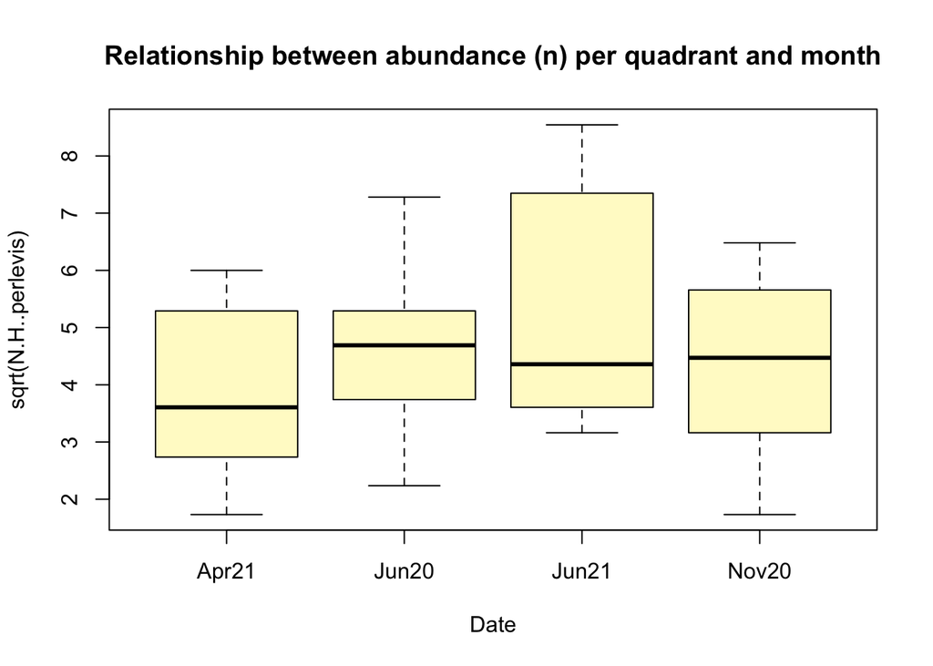

*Figure 1: Boxplot of the relationship between abundance (n) per quadrant and the month the measurement was taken.(x-axis): The month the abundance was measured for and (y-axis): the square root of the abundance.*

*Table 3: Chisq drop1 test results*

|  | npar | AIC | LRT | Pr(Chi) |
| --- | --- | --- | --- | --- |
|  | NA | 574.8655 | NA | NA |
| Date | 3 | 574.9404 | 6.074894 | 0.1080228 |

*Table 4: Generalised linear mixed effects model (GLMM) and posthoc tukey test*

```
##
##   Simultaneous Tests for General Linear Hypotheses
##
## Multiple Comparisons of Means: Tukey Contrasts
##
##
## Fit: glmer(formula = N.H..perlevis ~ Date + (1 | row_id), data = prey_ab_vol,
##     family = "poisson")
##
## Linear Hypotheses:
##                    Estimate Std. Error z value Pr(>|z|)
## Jun20 - Apr21 == 0   0.4080     0.2295   1.778   0.2826
## Jun21 - Apr21 == 0   0.5396     0.2312   2.333   0.0897 .
## Nov20 - Apr21 == 0   0.1873     0.2610   0.718   0.8895
## Jun21 - Jun20 == 0   0.1316     0.2051   0.642   0.9179
## Nov20 - Jun20 == 0  -0.2207     0.2382  -0.927   0.7895
## Nov20 - Jun21 == 0  -0.3523     0.2399  -1.469   0.4547
## ---
## Signif. codes:  0 '***' 0.001 '**' 0.01 '*' 0.05 '.' 0.1 ' ' 1
## (Adjusted p values reported -- single-step method)
```

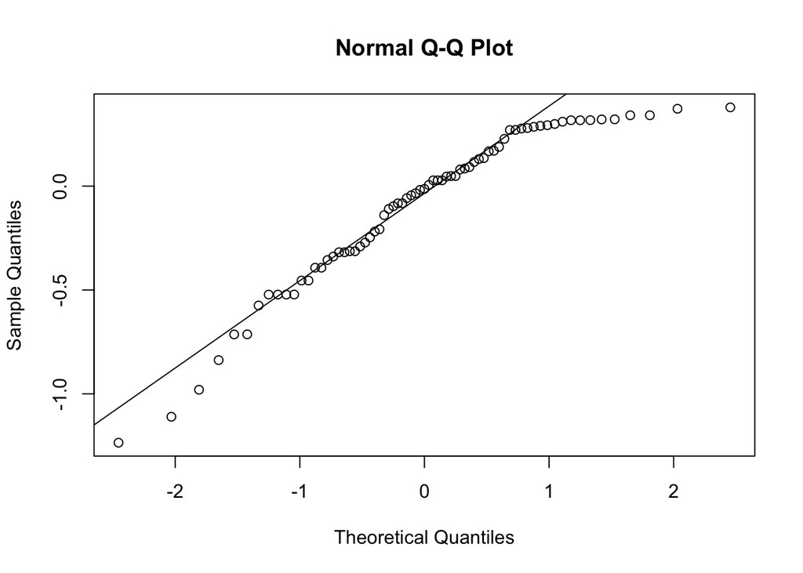

*Figure 2: QQ plot for GLMM model*